# Bankruptcy Prediction for Polish Enterprises

Olga Sieradzan, Jakub Wasiczek

2025-04-10

# Introduction

Corporate bankruptcy prediction is a critical area of financial analysis, with significant implications for investors, creditors, and policymakers. Accurate early warning systems can help mitigate risks, optimize decision-making, and ensure economic stability. Over the years, various statistical and machine learning models have been developed to assess the financial health of companies and predict their likelihood of failure.

This project explores and compares multiple predictive models for bankruptcy assessment, ranging from traditional econometric approaches to modern machine learning techniques. We evaluate the effectiveness of models such as the Altman Z-score (a classic discriminant analysis tool), legendary Tutson model, logistic regression, decision trees, random forests, and other advanced classifiers.

The aim of this project is to assest numerous models predictions on bancrupcy for polish companies between year 2000- 2013.

# Dataset

The dataset consist 64 variables conected to financial situation of each company and corresponding class label that indicates bankruptcy status after 1 year. The data contains 5910 instances (financial statements), 410 represents bankrupted companies, 5500 firms that did not bankrupt in the forecasting period.

There were some requirements set for data:

- No missing data - all of the rows with data gaps were deleted
- No high correlation between variables - variables with correlation hiher than 70% were deleted
- No data showing little variation - variables with variablility lower than 10% were deleted

After process of cleaning the traing set consist **23 variables and 140 observation (70 bancrupted and 70 not bancrupted)**, and the test set consist **23 variables and 64 observation (32 bancrupted and 32 not bancrupted)**

The 23 left variables:

- V2 - total liabilities / total assets
- V3 - working capital / total assets
- V4 - current assets / short-term liabilities
- V9 - sales / total assets
- V12 - gross profit / short-term liabilities
- V13 - (gross profit + depreciation) / sales
- V15 - (total liabilities * 365) / (gross profit + depreciation)
- V20 - (inventory * 365) / sales
- V21 - sales (n) / sales (n-1)
- V24 - gross profit (in 3 years) / total assets
- V28 - working capital / fixed assets
- V29 - logarithm of total assets
- V30 - (total liabilities - cash) / sales
- V33 - operating expenses / short-term liabilities
- V37 - (current assets - inventories) / long-term liabilities
- V43 - rotation receivables + inventory turnover in days
- V55 - working capital
- V57 - (current assets - inventory - short-term liabilities) / (sales - gross profit - depreciation)
- V59 - long-term liabilities / equity
- V60 - sales / inventory
- V61 - sales / receivables
- V64 - sales / fixed assets

While assesing models researchers used 2 quantatives ; model’s accuracy and false negative rate - how many % of bancruts were not discovered.

# Altman model

The Altman Z-Score is a classic financial model developed by Edward Altman in 1968 to predict the likelihood of corporate bankruptcy. It combines multiple financial ratios (such as profitability, leverage, liquidity, and efficiency) into a single discriminant score using a weighted formula. The original version for manufacturing firms is calculated as:

$$Z = 1.2X_1 + 1.4X_2 + 3.3X_3 + 0.6X_4 + 0.99X_5$$

represent ratios like working capital/total assets, retained earnings/total assets, EBIT/total assets, market value equity/total liabilities, and sales/total assets. Based on the Z-score, companies are classified as:

- Safe (Z > 2.99) – Low bankruptcy risk.
- Grey Zone (1.81 ≤ Z ≤ 2.99) – Moderate risk.
- Distress (Z < 1.81) – High bankruptcy risk.

**Results**

The table consist information about model’s performance.

| Actual | Predicted | Amount |
| --- | --- | --- |
| Alive | Alive | 32 |
| Alive | Grey area | 24 |
| Alive | Bancrupted | 14 |
| Bancrupted | Alive | 12 |
| Bancrupted | Grey area | 13 |
| Bancrupted | Bancrupted | 45 |

A lot of companies ended up in the grey area, which is a big disadvantage of this model. In the end, model should give as precised answer as possible.

| Accuracy | False Negative Rate | Method |
| --- | --- | --- |
| 55 | 35.770000000000003 | altman |

If it comes to model’s accuracy, it is really low - only 55%. The False negative rate on the other hand is a little bit over 35%, which is quite good, only 35% of bancrupted comapnies were not spotted.

Altman’s model, although brilliant for its time, has proven to be insufficient for the current Polish market. This may be due to the overly general nature of the model—the diagnostic variables and coefficients selected by Altman are not necessarily well-suited to companies across all markets, as they were estimated based on a very limited sample of firms from a single market. Moreover, it is worth noting that the data on which the model was built can now be considered outdated and no longer reflective of the realities faced by modern companies.

# Tutson model

The Tutson Model is an analytical tool researchers developed using linear discriminant analysis (LDA) tailored specifically for Polish companies. The model’s name is no accident—it pays tribute to a true master of motivation, an undisputed expert in stress management, and an unrivaled specialist in… sunbeam naps. Yes, I’m talking about Tutek, a chonky cat who not only provided moral support with his presence but also inspired groundbreaking solutions in finance and stock market analysis.

Thanks to his unwavering belief in success (and his knack for sitting on my keyboard at critical moments), the Tutsona Model became a symbol of combining academic precision with feline wisdom. It’s more than just an analytical tool—it’s a tribute to a true legend, proving that even the toughest challenges can be overcome with a bit of cat philosophy and a good nap.

**Results**

| Actual | Predicted | Freq | method |
| --- | --- | --- | --- |
| Alive | Alive | 24 | tutson |
| Bancrupted | Alive | 15 | tutson |
| Alive | Bancrupted | 8 | tutson |
| Bancrupted | Bancrupted | 17 | tutson |

| Accuracy | False Negative Rate | Method |
| --- | --- | --- |
| 64.06 | 46.87 | tutson |

Accuracy achieved by LDA model made specifically for Polish market, is visibly higher than Altman’s model outcome. Unfortunately, it’s still low, and False Negative rate is beyond disappointing.

The downfall of the Tutson model can be easily explained. Linear Discriminant Analysis (LDA) is a method that relies on several statistical assumptions—none of which were met by our dataset. First and foremost, LDA assumes that the predictor variables follow a normal distribution. In addition, it requires that all classes have equal covariance matrices. These assumptions are difficult to uphold in real-world data, which is one of the reasons behind the declining popularity of LDA in practical modeling applications.

Over the past decade, a number of more flexible algorithms have been introduced and widely adopted in the financial sector. These include methods such as Random Forests, Gradient Boosting Machines, and Neural Networks. These newer approaches typically make fewer assumptions about the data and are better equipped to handle complex, non-linear relationships.

But are they truly that much better? While they often outperform traditional methods like LDA in terms of predictive accuracy, they come with their own trade-offs—such as increased computational complexity, reduced interpretability, and a higher risk of overfitting if not properly tuned. Ultimately, the choice of algorithm should depend on the specific context, data characteristics, and the balance between accuracy and explainability required by the stakeholders.

# LDA Models form literature

Tutson model is a simple tool, built on small dataset and small knowlage. There are many tries in literature to employ Altman’s idea for Polish companies, and try to predict bancrupcy. We chose to test two models: *E. Mączyńska’s model* and *Poznański model*.

## E. Mączyńska’s model

First, we’ve decided to test *E. Mączyńska’s model* which presents as follows:  
$Z(M) = 9,478X_{1} + 3,613X_{2} + 3,246X_{3} + 0,455X_{4} + 0,802X_{5} - 2,478$

Where:

- X1 - profit on operating activities / total assets
- X2 - equity / total assets
- X3 - (net profit + depreciation) / total liabilities
- X4 - current assets / short-term liabilities
- X5 - (sales + profit on operating activities) / total assets

The model contains a constant, so the interpretation is pretty straightforward:

- Z(M) > 0 - no-default
- Z(M) <= 0 - default

**Results**

| Actual | Predicted | Freq | method |
| --- | --- | --- | --- |
| Alive | Alive | 28 | maczynski |
| Bancrupted | Alive | 18 | maczynski |
| Alive | Bancrupted | 4 | maczynski |
| Bancrupted | Bancrupted | 14 | maczynski |

| Accuracy | False Negative Rate | Method |
| --- | --- | --- |
| 65.63 | 56.25 | maczynski |

The attemopt was made, but still the LDA seems dissapointing on this type of data. The accuracy aroung 65% and False Negative rate arund 56% indiciates rather poor quality of E. Mączyńska’s model, but it has the highest accuracy out of all LDA models tested in this research.

## Poznański model

The *Poznański model* formula is:

$Z(P) = 3,562X_{1} + 1,58*X_{2} + 4,288X_{3} + 6,719X_{4} - 2,368$

Where:

- X1 - net profit / total assets
- X2 - (current assets - inventory) / short-term liabilities
- X3 - (equity + long-term liabilities) / total assets
- X4 - gross profit / sales

The interpretation is the same as in *Mączyńska’s model*:

- Z(P) > 0 no-default
- Z(P) <= 0 default

**Results**

| Actual | Predicted | Freq | method |
| --- | --- | --- | --- |
| Alive | Alive | 22 | poznanski |
| Bancrupted | Alive | 12 | poznanski |
| Alive | Bancrupted | 10 | poznanski |
| Bancrupted | Bancrupted | 20 | poznanski |

| Accuracy | False Negative Rate | Method |
| --- | --- | --- |
| 65.625 | 37.5 | poznanski |

Poznański model performed comparable to the previously mention model for polish companies. Yet still, the resulats are dissapointing.

# Quadratic Discriminant Analysis

Quadratic Discriminant Analysis (QDA) is an extension of LDA that relaxes the assumption of equal class covariances. While this makes QDA more flexible, it comes at a cost: instead of estimating a single covariance matrix with $p(p+1)/2$ parameters (where *p* is the number of predictors), QDA requires estimating a separate covariance matrix for each class, resulting in $K*p(p+1)/2$ parameters. This significantly increases the variance of the estimators, which is why QDA isn’t always preferred over LDA — especially with limited data.

**Results**

| Actual | Predicted | Freq | method |
| --- | --- | --- | --- |
| Alive | Alive | 26 | qda |
| Bancrupted | Alive | 10 | qda |
| Alive | Bancrupted | 6 | qda |
| Bancrupted | Bancrupted | 22 | qda |

| Accuracy | False Negative Rate | Method |
| --- | --- | --- |
| 75 | 31.25 | qda |

If it comes to accuracy, it improved significantly, compared to previous two results. Result equal to 75% seems reasonable and quite satisfying. Additionally, QDA achived lowest False Negative Rate out of all already researched methods. Relaxing of the assumption of equal class covariances, gave very promising result.

# Naive Bayes

Naive Bayes makes a strong assumption that all predictors are independent. This means the joint probability of the predictor vector *X* belonging to class *k* is simply the product of the individual predictor densities. In practice, this assumption rarely holds—especially in our case, where many financial ratios are derived from overlapping data. However, since we initially removed highly correlated variables, Naive Bayes may still perform reasonably well.

**Results**

| Actual | Predicted | Freq | method |
| --- | --- | --- | --- |
| Alive | Alive | 25 | naive bayes |
| Bancrupted | Alive | 11 | naive bayes |
| Alive | Bancrupted | 7 | naive bayes |
| Bancrupted | Bancrupted | 21 | naive bayes |

| Accuracy | False Negative Rate | Method |
| --- | --- | --- |
| 71.875 | 34.375 | naive bayes |

Al thought the assumption was not met, naive baias performed quite well, better then the LDA but slighty worse than QDA model. The False negative rate thought is still disappointing. Naive Bayes has not occurred as groundbreaking method, and the exploration for better models shall not stop.

# Logistic Regression

Logistic regression is a statistical method used to predict binary outcomes (e.g., bankruptcy vs. solvency) by modeling the probability of an event occurring. Unlike linear regression, it uses the logistic function (sigmoid curve) to output values between 0 and 1, interpreted as the likelihood of default. While less flexible than ML algorithms, it remains a benchmark tool for financial distress analysis. In this study, the treshold for assesing brancrupcy is: 50%> - bancrupted, 50%=< - not bancrupted. Manipulation of this treshold can give intresting results in Accuracy or False Negative rates

**Results - 50% threshold**

| Actual | Predicted | Freq | method |
| --- | --- | --- | --- |
| Alive | Alive | 22 | logistic regression |
| Bancrupted | Alive | 7 | logistic regression |
| Alive | Bancrupted | 10 | logistic regression |
| Bancrupted | Bancrupted | 25 | logistic regression |

| Accuracy | False Negative Rate | Method |
| --- | --- | --- |
| 73.4375 | 21.875 | logistic regression |

**Results - 80% threshold**

Managing verges of threshold is additional feature that logistic regression is offering. Firstly, it is research, how increasing threshold to as much as 80% will affect model’s rates.

| Accuracy | False Negative Rate | Method |
| --- | --- | --- |
| 59.375 | 56.25 | lr08 |

Results are of course dissapointing, but it was easy to predict. More intresting results are obtaing by lowering the threshold to jus 10%.

**Results - 10% threshold**

Lowering threshold may occure very usefull, because model will be ‘more carefull’.

| Accuracy | False Negative Rate | Method |
| --- | --- | --- |
| 70.31 | 18.75 | lr01 |

As assumed, while accuracy might not be wonderful, the False Negative Rate is. Logistic Regression with 10% threshold has come out as the best in detecting bankrupted companies, which is a very valuable feature. For the bank, it will be more important not to lend money to soon bankrupted comapny than not to lend money to company doinbg okay.

# XGBoost (Extreme Gradient Boosting)

XGBoost (Extreme Gradient Boosting) is a powerful machine learning algorithm that excels at predicting bankruptcy by combining multiple weak “decision trees” into a highly accurate ensemble model. Model iteratively corrects errors from previous trees, focusing on “hard-to-predict” cases. Additionaly it Handles non-linear patterns, missing data, and imbalanced datasets (common in bankruptcy cases). Built-in regularization prevents overfitting, making it robust even with small financial datasets.

For example, XGBoost might detect complex interactions between profitability ratios and market conditions that simpler models miss. While less interpretable than logistic regression, its performance often dominates in predictive accuracy.

In this research 200 rounds of “boosting” were performed. Reserchers belive this number performed the best out of all tested and prevent overfiting of model. Additionally, binary function of aim was used.

**Results**

| Actual | Predicted | Freq | method |
| --- | --- | --- | --- |
| Alive | Alive | 28 | xgb |
| Bancrupted | Alive | 15 | xgb |
| Alive | Bancrupted | 4 | xgb |
| Bancrupted | Bancrupted | 17 | xgb |

| Accuracy | False Negative Rate | Method |
| --- | --- | --- |
| 70.31 | 46.88 | xgb |

XGBoost algorithm, althought very complex, with this amount of data performed disappointingly. It did not achive results significantly higher than other models, and Flase negative rate came out definitly too high.

# Random Forest Model

The Random Forest model is an ensemble machine learning method that builds multiple decision trees and merges their predictions to improve accuracy and reduce overfitting. Model trains hundreds of decision trees on random subsets of data (bagging) and features (feature randomness). Combines their votes (for classification) or averages their outputs (for regression). This model handles non-linear relationships and high-dimensional data (e.g., dozens of financial ratios),althought it’s less interpretable than single decision trees, it’s more accurate.

**Results**

| Actual | Predicted | Freq | method |
| --- | --- | --- | --- |
| Alive | Alive | 27 | random forest |
| Bancrupted | Alive | 14 | random forest |
| Alive | Bancrupted | 5 | random forest |
| Bancrupted | Bancrupted | 18 | random forest |

| Accuracy | False Negative Rate | Method |
| --- | --- | --- |
| 70.3125 | 43.75 | random forest |

Situation seems the same as in the XGB algorithm. The amount of data is not sufficient, which led to disappointing results. The accuracy is the same as in the previous method, and False Negative rate is slightly better but still not satisfying.

# Model comparasion

The aim of the research, is to not only to show potential methods to resolve problem of bancrupcy prediction, but also to assest those method and petencially choose the best one.

**Accuracy**

One of the rates, used to asset model is accuracy, the percent of correctly predicted states of company (bankrupted/alive). It is wanted , that model has very high accuracy.

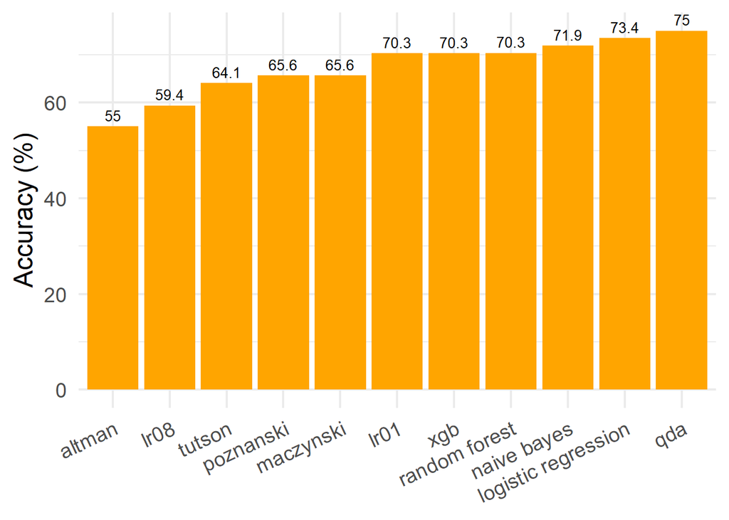

The QDA method has achived the highest accuracy of all of the models, but it is important to mention that differences between most of the models are not really significant. Definitely, altman model, tutson model and logistic regression with high threshold, are the worst of all researched methods and can be defined as not really promising. Machine learning algorithms performed disappointingly, it did not occur significantly better than statistical method as it may seem at first.

**False Negative Rate**

Second used rate to asset models is False negative rate, which is better if lower.

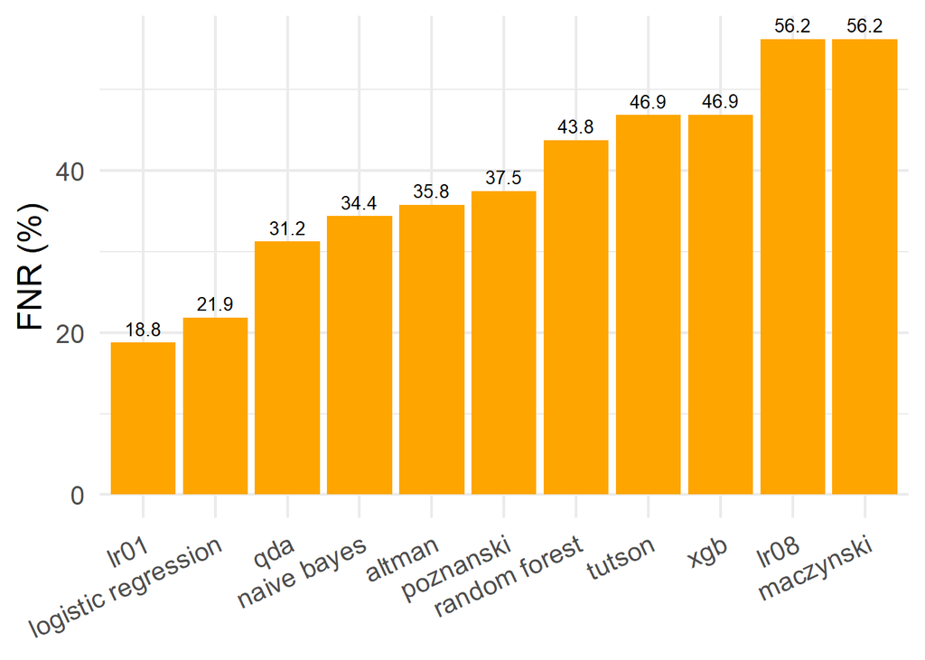

If it comes to FNR, it can be seen that results have a lot wider range that accuracy results. From Logistic Regressioin with a less that 19% to Maczyński Model with more than 55%. The QDA which was the best in accuracy results also performed quite well in False Negative Rate.

# Large traing set senerio

Since the project was initially based on a limited dataset—focusing only on companies one year before bankruptcy—we now aim to test whether including a new variable, “Number of years before bankruptcy,” can improve prediction performance. We created much bigger dataset to perform additional analysys. Large training set consist over 1000 rows, and new column. With this much data, not all of the models were compatible. we choose LDA and Random Forest because those methods were successful with training on this amount of information. By expanding the dataset in this way, we increase the sample size, which gives us reason to believe that the models may achieve better results.

## LDA

| Actual | Predicted | Freq | method |
| --- | --- | --- | --- |
| Alive | Alive | 14114 | large set LDA |
| Bancrupted | Alive | 16 | large set LDA |
| Alive | Bancrupted | 5112 | large set LDA |
| Bancrupted | Bancrupted | 113 | large set LDA |

| Accuracy | False Negative Rate | Method |
| --- | --- | --- |
| 73.50555 | 12.4031 | large set LDA |
| 64.06000 | 46.8700 | tutson |

Compering to the previous attempt to build LDA model for polish compainies (Tutson Model), using expended dataset gave siginificantly better results. The accuracy is higher, but still not groundbreaking, QDA model achieved similiar one. If it comes to FNR, we can definitly say this is a success. For a large dataset LDA model, mistakenly predicted barcrupted company as alive only 12% times, which is the lowest score achived by all of the researched models.

## Random Forest

| Actual | Predicted | Freq | method |
| --- | --- | --- | --- |
| Alive | Alive | 14878 | large set random forest |
| Bancrupted | Alive | 14 | large set random forest |
| Alive | Bancrupted | 4348 | large set random forest |
| Bancrupted | Bancrupted | 115 | large set random forest |

| Accuracy | False Negative Rate | Method |
| --- | --- | --- |
| 70.31250 | 43.75000 | random forest |
| 77.46319 | 10.85271 | large set random forest |

Random Forest model also performed better while having access to more information. It achieved the highes accuracy out of all models that were researched, and the lowest FNR, which definetly makes it the best performing model of all.

# Conclusions

The primary objective of this research was to present and assess various methods used for bankruptcy prediction. The study involved the application of both traditional statistical techniques and modern machine learning algorithms. By comparing their predictive performance on relevant financial datasets, the researchers aimed to evaluate their respective strengths, weaknesses, and practical applicability.

Although machine learning is currently experiencing rapid development and widespread adoption across industries, this research shows that statistical models still hold significant value. They should not be dismissed, especially in financial decision-making processes where explainability and robustness are essential.

In conclusion, the best results in bankruptcy prediction may often come from a thoughtful combination of both worlds. Hybrid approaches that blend the interpretability of statistical models with the predictive power of machine learning could offer a balanced and effective solution for practitioners and stakeholders in the financial sector.